# Analysis of hunting effects on spatial structure of trees with different dispersers

### 3.2 Bivariate Model

#### 3.2.1 Fit bivariate model

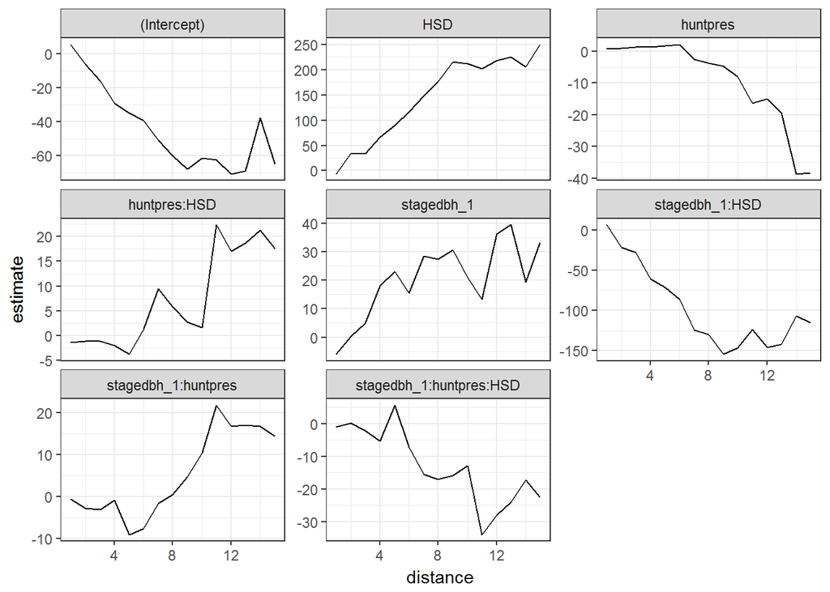

```r
hyperdat.bi.sel.c <- subset(hyperdat.bi.sel.c,
                             !(
                               site == "BM" & sp.id %in% c(562) |
                               site == "LA" & sp.id %in% c(379, 376, 612, 735) |
                                 site == "CashuTr12"& sp.id %in% c(635, 563) |
                                 site == "CashuTr3" & sp.id %in% c(708, 562) |
                                 site == "RA" & sp.id %in% c(552, 293)
                               ))


## Full models with Juveniles and saplings (pair2)
intMod.bi <- klmerHyper(K~stage*huntpres*HSD + (1|site/Spp), hyper=hyperdat.bi.sel.c,
                         weights=wts, r=0:rmax, correction="border")
plot(intMod.bi)
```

#### 3.2.2 Model diagnostics

Checking the model diagnostics for the interactive bivariate model

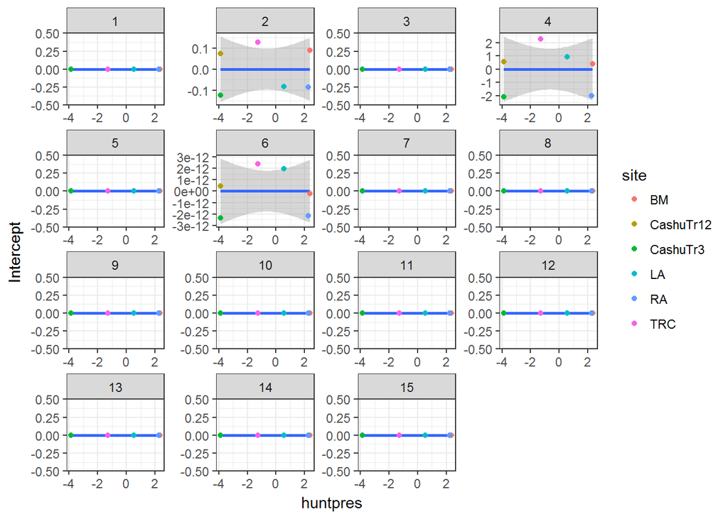

```r
## site level random effects
intMod.bi.ranefs <- extractModRanefs(intMod.bi)
intMod.bi.ranefs <- intMod.bi.ranefs %>% separate(group, into=c('Spp', 'site'),
                                                    sep=":", fill="left")

intMod.bi.ranefs$huntpres <- sitedat$huntpres[match(intMod.bi.ranefs$site,
                                                     sitedat$site)]

subset(intMod.bi.ranefs, level=="site") %>% ggplot(aes(x=huntpres, y=Intercept)) +
  geom_smooth(method='gam', method.args=list(k=5)) + geom_point(aes(col=site)) +
  facet_wrap(~distance, scale='free') + theme_bw()
```

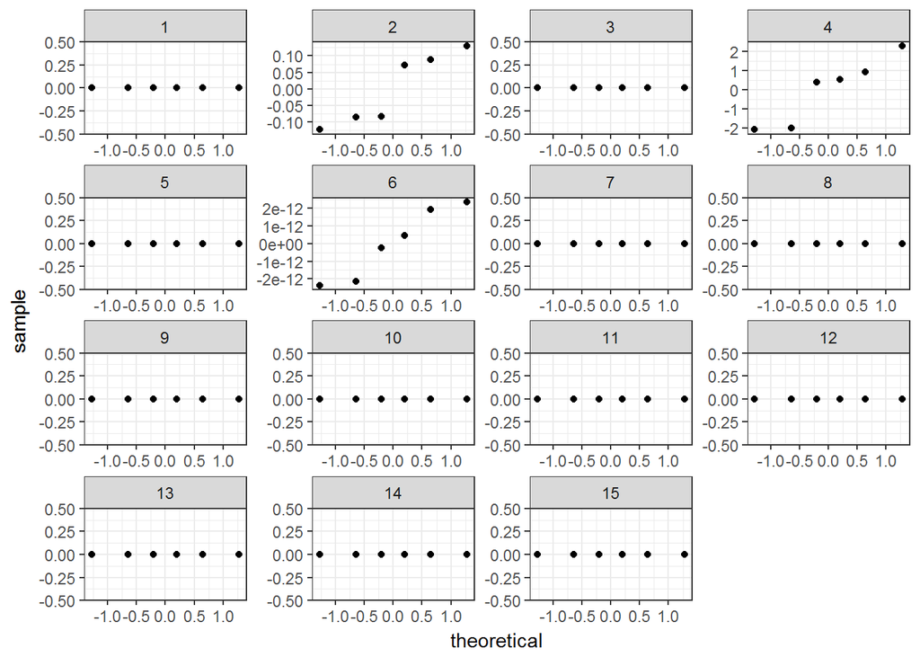

```r
## almost no between site variation - tempting to drop the random effect,
# but that would probably be sacrificial pseudoreplication
subset(intMod.bi.ranefs, level=="site") %>% ggplot(aes(sample=Intercept)) + geom_qq() +
  facet_wrap(~distance, scale='free') + theme_bw()
```

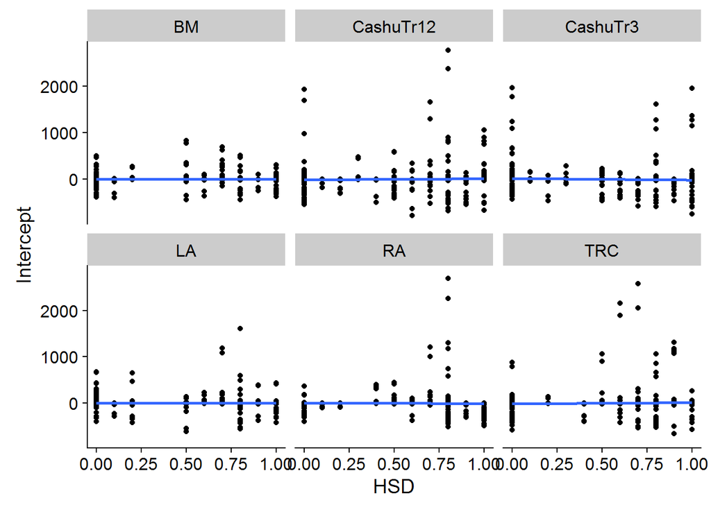

```r
## species level random effects
intMod.bi.ranefs$HSD <- dispersal$HSD[match(intMod.bi.ranefs$Spp, dispersal$Spp)]

subset(intMod.bi.ranefs, level=="Spp:site") %>%
  ggplot(aes(x=HSD, y=Intercept)) + geom_point() +
  geom_smooth(method='gam', method.args=list(k=5)) + facet_wrap(~site)
```

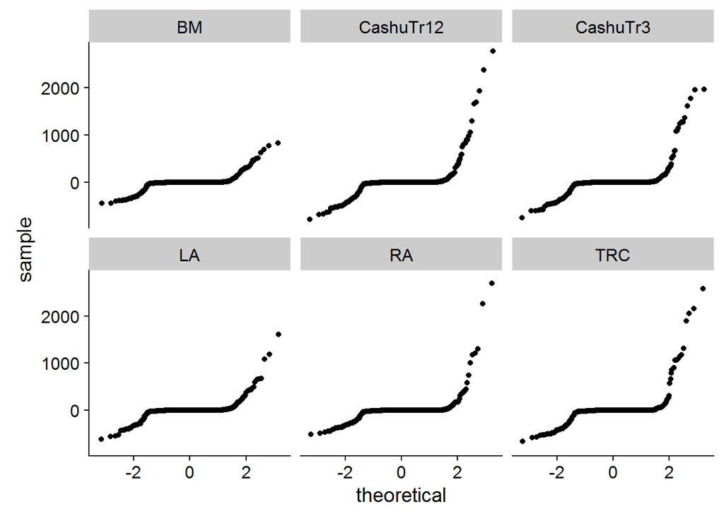

```r
subset(intMod.bi.ranefs, level=="Spp:site") %>%
  ggplot(aes(sample=Intercept)) + geom_qq() + facet_wrap(~site)
```

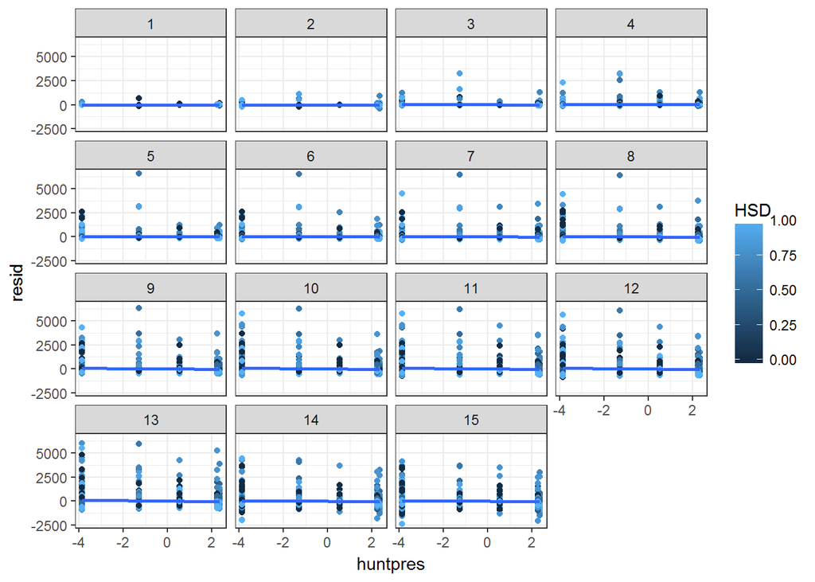

```r
## Again, not ideal if we were making parametric assumptions - but we
## are bootstrapping (semi-parametrically) so these aren't too bad. That said,
## perhaps worth looking at some of those LA values

resids.bi <- extractModResids(intMod.bi)

## add data on species names
resids.bi$species <- rep(hyperdat.bi.sel.c$Spp, 15)
resids.bi$sp.id <- rep(hyperdat.bi.sel.c$sp.id, 15)
resids.bi$N1 <- rep(hyperdat.bi.sel.c$N1, 15)
resids.bi$N2 <- rep(hyperdat.bi.sel.c$N2, 15)


resids.bi %>% ggplot(aes(x=huntpres, y=resid, colour=HSD)) +
   facet_wrap(~distance) +
   geom_point() + geom_smooth(method='gam', method.args=list(k=4)) +
   theme_bw()
```

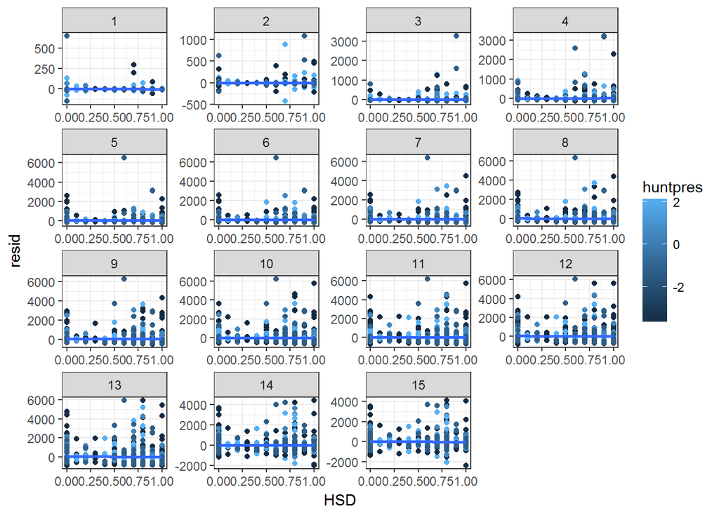

```r
resids.bi %>% ggplot(aes(x=HSD, y=resid, colour=huntpres)) +
   facet_wrap(~distance, scale='free') +
   geom_point() + geom_smooth(method='gam', method.args=list(k=4)) +
   theme_bw()
```

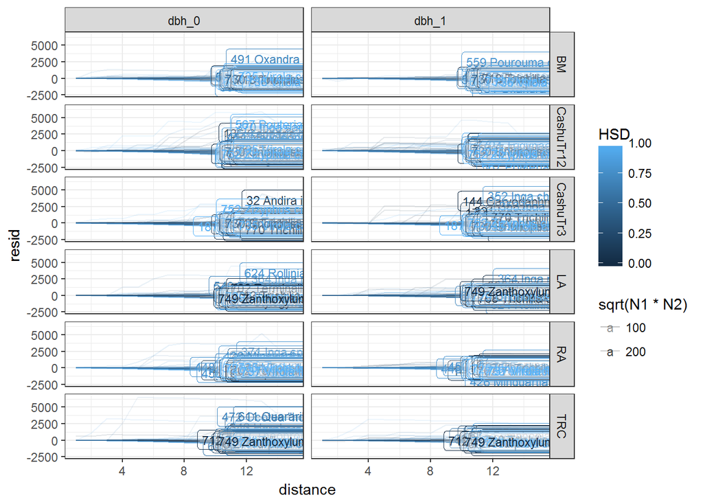

```r
ggplot(data=resids.bi, aes(x=distance, y=resid, colour=HSD, group=species, alpha=sqrt(N1*N2))) +
       geom_line() +
   geom_label(data=subset(resids.bi, distance ==15),
                                  aes(label=paste(sp.id, species), x=distance, y=resid), size=3) +
  facet_grid(site~stage) +
   theme_bw()
```

### 3.4 Interactive model confidence intervals

```r
## construct data to make predictions for figures with
preddat.int <-  expand.grid(stage=levels(hyperdat.uni.sel.c$stage),
                            huntpres=round(quantile(sitedat$huntpres, seq(0, 1, 0.25)), 1),
                            HSD = seq(0, 1, 0.25))
## RHS of model formula
allform <- update(formula(intMod.uni[[1]], fixed.only=TRUE), NULL~.)

## Make model matrix
modmat.int <-  model.matrix(allform, data=preddat.int)

## Bootstrapping
## Univariate
system.time(intMod.uni_ci <-  confint(intMod.uni, lin_comb =modmat.int, nboot=nsim,
                                       level=0.95, ncore=7, iseed=1234))
```

```
## clusters closed on exit
```

```
##    user  system elapsed
##    1.64    0.33  189.39
```

```r
## bivariate
system.time(intMod.bi_ci <-  confint(intMod.bi, lin_comb =modmat.int, nboot=nsim,
                                       level=0.95, ncore=7, iseed=1234))
```

```
## clusters closed on exit
```

```
##    user  system elapsed
##    1.62    0.30  133.50
```

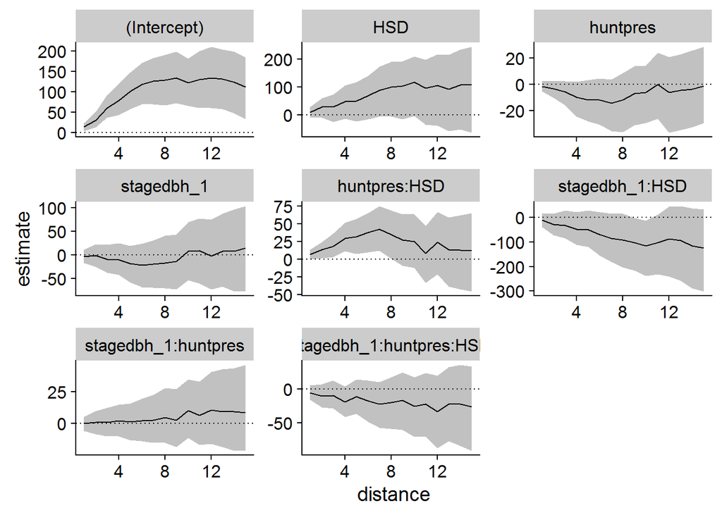

```r
##save(intMod.uni_ci, file="../results/v8.0/intModUni.RData")
# load(file="../results/v8.0/intModUni.RData")

plot(intMod.uni_ci)
```

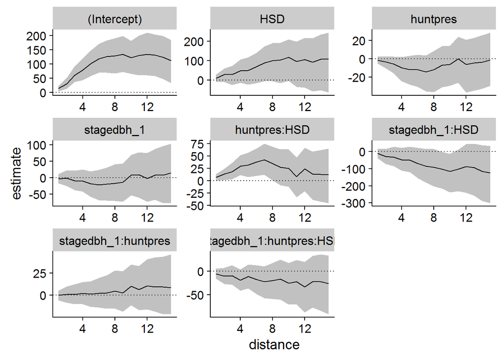

```r
##save(intMod.bi_ci, file="../results/v8.0/intModBi.RData")
#load(file="../results/v8.0/intModBi.RData")
## plot them both
plot(intMod.uni_ci)
```

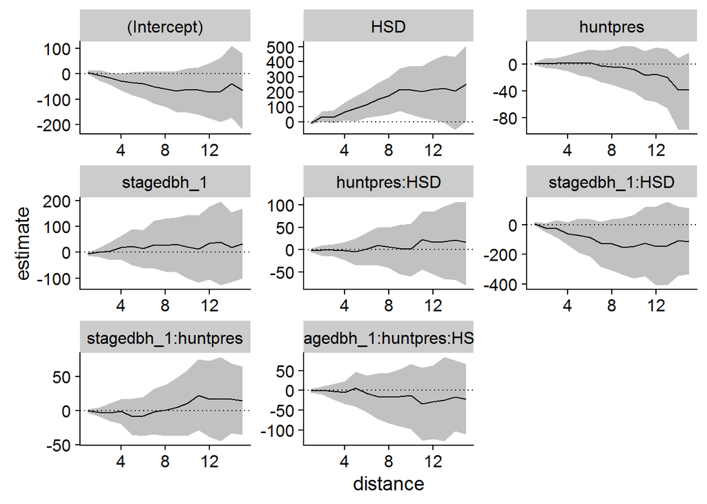

```r
plot(intMod.bi_ci)
```

### 3.5 Formal tests of hypotheses 2 and 3

### 3.5.1 Univariate

The formal anova tests of the full model are very time consuming. It is better to do this on a cluster. First we look at the univariate case

```r
## Main effects model
intMod.uni.1way <- klmerHyper(K~stage + huntpres + HSD + (1|site/Spp),
                            hyper=hyperdat.uni.sel.c, weights=wts,
                            r=0:rmax, correction="border")

## 2 way interaction model
intMod.uni.2way <- klmerHyper(K~(stage + huntpres + HSD)^2 + (1|site/Spp),
                            hyper=hyperdat.uni.sel.c, weights=wts,
                            r=0:rmax, correction="border")
modmat.int2way <-  model.matrix(update(formula(intMod.uni.2way[[1]], fixed.only=TRUE),
                                       NULL~.), data=preddat.int)


## Test main effects
anova.int.uni.1way  <- sapply(c('stage', 'huntpres', 'HSD'), function(term)
{
  print(term)
  anova(intMod.uni.1way, term=term,
        dists=distlist, nboot=nsim, ncore=7, iseed=1234)
}, simplify=FALSE)
```

```
## [1] "stage"
## [1] "clusters closed on exit"
## [1] "huntpres"
## [1] "clusters closed on exit"
## [1] "HSD"
## [1] "clusters closed on exit"
```

```r
## test 2 way interactions
anova.int.uni.2way  <- sapply(c('stage:huntpres', 'stage:HSD', 'huntpres:HSD'), function(term)
{
  print(term)
  anova(intMod.uni.2way, term=term,
        dists=distlist, nboot=nsim, ncore=7, iseed=1234)
}, simplify=FALSE)
```

```
## [1] "stage:huntpres"
## [1] "clusters closed on exit"
## [1] "stage:HSD"
## [1] "clusters closed on exit"
## [1] "huntpres:HSD"
## [1] "clusters closed on exit"
```

```r
## Test 3- way interaction
## 3-way interaction
anova.int.uni.3way <-
  anova(intMod.uni, term="stage:huntpres:HSD",
        dists=distlist, nboot=nsim, ncore=7, iseed=1234)
```

```
## [1] "clusters closed on exit"
```

```r
## Put them all together in an easily read table
intMod.uni.aov <- c(anova.int.uni.1way, anova.int.uni.2way, "stage:huntpres:HSD" = list(anova.int.uni.3way))

##save(intMod.uni.aov, file="../results/v8.0/aov_intModuni.RData")

##load("../results/v8.0/aov_intModuni.RData")

(anovatable.int.uni <- do.call('cbind', lapply(1:4, function(i)
  t(sapply(intMod.uni.aov, function(x) x$T[[i]]$stat)))))
```

|  | T | p | T | p | T | p | T | p |
| --- | --- | --- | --- | --- | --- | --- | --- | --- |
| stage | 3.522 | 0.029 | 3.401 | 0.044 | 5.924 | 0.019 | 1.240 | 0.262 |
| huntpres | 0.081 | 0.992 | 0.014 | 0.999 | 0.151 | 0.812 | 0.077 | 0.911 |
| HSD | 0.283 | 0.820 | 0.027 | 0.997 | 0.310 | 0.661 | 0.512 | 0.492 |
| stage:huntpres | 0.453 | 0.694 | 0.941 | 0.356 | 0.386 | 0.617 | 0.034 | 0.970 |
| stage:HSD | 1.528 | 0.203 | 0.834 | 0.387 | 2.329 | 0.120 | 1.423 | 0.226 |
| huntpres:HSD | 1.476 | 0.205 | 2.841 | 0.058 | 1.535 | 0.209 | 0.054 | 0.931 |
| stage:huntpres:HSD | 1.121 | 0.305 | 1.392 | 0.231 | 1.147 | 0.289 | 0.824 | 0.374 |

### 3.5.2 Bivariate

Then we look at the bivariate case

```r
## Main effects
intMod.bi.1way <- klmerHyper(K~stage + huntpres + HSD + (1|site/Spp),
                            hyper=hyperdat.bi.sel.c, weights=wts,
                            r=0:rmax, correction="border")

## 2 way interactions model
intMod.bi.2way <- klmerHyper(K~(stage + huntpres + HSD)^2 + (1|site/Spp),
                            hyper=hyperdat.bi.sel.c, weights=wts,
                            r=0:rmax, correction="border")

anova.int.bi.1way  <- sapply(c('stage', 'huntpres', 'HSD'), function(term)
{
  print(term)
  anova(intMod.bi.1way, term=term,
        dists=distlist, nboot=nsim, ncore=7, maxit=50, iseed=1234)
}, simplify=FALSE)
```

```
## [1] "stage"
## [1] "clusters closed on exit"
## [1] "huntpres"
## [1] "clusters closed on exit"
## [1] "HSD"
## [1] "clusters closed on exit"
```

```r
anova.int.bi.2way  <- sapply(c('stage:huntpres', 'stage:HSD', 'huntpres:HSD'), function(term)
{
  print(term)
  anova(intMod.bi.2way, term=term, dists=distlist, nboot=nsim, ncore=7, maxit=50, iseed=1234)
}, simplify=FALSE)
```

```
## [1] "stage:huntpres"
## [1] "clusters closed on exit"
## [1] "stage:HSD"
## [1] "clusters closed on exit"
## [1] "huntpres:HSD"
## [1] "clusters closed on exit"
```

```r
## 3-way interaction
anova.int.bi.3way <-  anova(intMod.bi, term="stage:huntpres:HSD",
        dists=distlist, nboot=nsim, ncore=7, iseed=1234, maxit=50)
```

```
## [1] "clusters closed on exit"
```

```r
intMod.bi.aov <- c(anova.int.bi.1way, anova.int.bi.2way, "stage:huntpres:HSD" = list(anova.int.bi.3way))

save(intMod.bi.aov, file="../results/v8.0/aov_intModbi.RData")


anovatable.int.bi <- do.call('cbind', sapply(1:4, function(i, d)
  {
    tab <- rbind(t(sapply(anova.int.bi.1way, function(x) x$T[[i]]$stat)),
                 t(sapply(anova.int.bi.2way, function(x) x$T[[i]]$stat)),
                 t(anova.int.bi.3way$T[[i]]$stat))
    rownames(tab)[7] <- "stage:huntpres:HSD"
    colnames(tab) <- paste0(colnames(tab), " (",
                            paste(range(d[[i]]), collapse=":"), ")")
    return(tab)

}, d=distlist, simplify=FALSE))

anovatable.int.bi
```

|  | T (1:15) | p (1:15) | T (1:5) | p (1:5) | T (6:10) | p (6:10) | T (11:15) | p (11:15) |
| --- | --- | --- | --- | --- | --- | --- | --- | --- |
| stage | 0.636 | 0.558 | 0.695 | 0.508 | 0.741 | 0.420 | 0.471 | 0.553 |
| huntpres | 0.605 | 0.642 | 0.421 | 0.779 | 0.454 | 0.562 | 0.941 | 0.396 |
| HSD | 3.956 | 0.007 | 2.557 | 0.047 | 6.640 | 0.006 | 2.670 | 0.067 |
| stage:huntpres | 0.650 | 0.549 | 1.284 | 0.266 | 0.544 | 0.510 | 0.122 | 0.856 |
| stage:HSD | 1.500 | 0.191 | 1.885 | 0.137 | 1.880 | 0.161 | 0.735 | 0.414 |
| huntpres:HSD | 0.121 | 0.996 | 0.277 | 0.851 | 0.038 | 0.972 | 0.048 | 0.983 |
| stage:huntpres:HSD | 0.175 | 0.944 | 0.090 | 0.981 | 0.166 | 0.812 | 0.270 | 0.697 |

```r
#
```

## 4 Plots

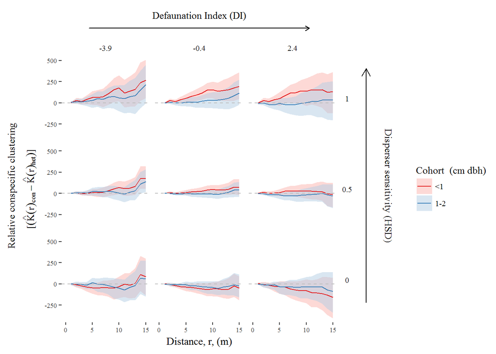

```r
################################################################################
## extract predictions and cis from model output
int.bi.plotdat <- klmerci2plot(intMod.bi_ci, preddat=preddat.int)
int.uni.plotdat <- klmerci2plot(intMod.uni_ci, preddat=preddat.int)

names(int.bi.plotdat)[5:7] <- paste(names(int.bi.plotdat)[5:7], 'bi', sep='.')
names(int.uni.plotdat)[5:7] <- paste(names(int.uni.plotdat)[5:7], 'uni', sep='.')
## Combine within and between cohort results
int.plotdat <- full_join(int.uni.plotdat, int.bi.plotdat,
                     by=c('distance', 'stage','huntpres', 'HSD'), suffix=c('.uni', ".bi"))

## More reader friendly labels


int.plotdat$stage <- factor(int.plotdat$stage,
                            labels=dbhlabs)
int.plotdat$huntpres <-  round(int.plotdat$huntpres, 1)

# int.plotdat$huntpres <-  factor(int.plotdat$huntpres, labels=c('Low', 'High'))
# int.plotdat$HSD <-  factor(int.plotdat$HSD, labels=c('Insensitive', 'Sensitive'))

## stat = identity hardwires the order - fixing so that isn't a problem
int.plotdat <- int.plotdat[order(int.plotdat$distance),]

int.plotdat <- subset(int.plotdat, huntpres %in% c(-3.9, -0.4, 2.4) & HSD %in% c(0, 0.5, 1))

## Make plots
pl.int.bi <-
    ggplot(int.plotdat, aes(x=distance, y=est.bi, ymin=lcl_pred.bi, ymax=ucl_pred.bi,
                    colour=stage, fill=stage)) +
    geom_ribbon(alpha=0.5, colour=NA) +  geom_line() +
    facet_grid(HSD~  huntpres, as.table=FALSE) +
    geom_abline(intercept=0, slope=0, linetype='dashed', col='grey') +
    theme_tufte() + theme_cust +
    scale_x_continuous(limits=c(0, 15)) +
    scale_color_brewer(palette='Set1')+ scale_fill_brewer(palette='Pastel1') +

    labs(x='Distance, r, (m)',
         y=expression(paste('[', (hat(K)(r)[con]-hat(K)(r)[het]), ']')),
        color='Cohort  (cm dbh)', fill='Cohort  (cm dbh)')

pl.int.uni <-
  ggplot(int.plotdat, aes(x=distance, y=est.uni, ymin=lcl_pred.uni, ymax=ucl_pred.uni,
             colour=stage, fill=stage, group=stage)) +
  geom_ribbon(alpha=0.5, colour=NA) +  geom_line() +
  facet_grid(HSD~  huntpres, as.table=FALSE) +
  geom_abline(intercept=0, slope=0, linetype='dashed', col='grey') +
  theme_tufte() + theme_cust +
  scale_x_continuous(limits=c(0, 15)) +
  scale_color_brewer(palette='Set1')+ scale_fill_brewer(palette='Pastel1') +
  labs(x='Distance, r, (m)',
       y=expression(paste('[', (hat(K)(r)[con]-hat(K)(r)[het]), ']')),
         color='Cohort (cm dbh)', fill='Cohort (cm dbh)')

## Format figures (2 and 3)
z.bi <- ggplot_gtable(ggplot_build(pl.int.bi))


##gtable_show_layout(z.bi)
## add a label at the top and side
z.bi <- gtable_add_rows(z.bi, height=unit(z.bi$heights[[6]], 'cm'), pos=5)
z.bi <- gtable_add_rows(z.bi, height=unit(z.bi$heights[[6]], 'cm'), pos=5)
z.bi <- gtable_add_cols(z.bi, width=unit(z.bi$widths[[9]], 'cm'), pos=9)
z.bi <- gtable_add_cols(z.bi, width=unit(z.bi$widths[[9]], 'cm'), pos=9)
z.bi <- gtable_add_cols(z.bi, width=z.bi$widths[[2]], pos=1)

z.bi <- gtable_add_grob(z.bi,
                     list(rectGrob(gp = gpar(fill=NA, col=NA, lwd=0)),
                          textGrob("Relative conspecific clustering", rot = 90,
                                   gp = gpar(fontsize=10, fontfamily="serif"))),
                     t=8, l=2, b=14, r=2, name = paste(runif(2)))


z.bi <- gtable_add_grob(z.bi,
                     list(rectGrob(gp=gpar(fill=NA, col=NA, lwd=0)),
                          textGrob("Defaunation Index (DI)",
                                   gp = gpar(fontsize=10, fontfamily="serif"))),
                     t=6, l=5, b=6, r=9, name = paste(runif(2)))

z.bi <- gtable_add_grob(z.bi,
                        linesGrob(x=seq(0.1, 0.9, 0.1), y=rep(0.7, 9),
                                  arrow=arrow(angle=30, length=unit(0.3, "npc"))),
                        t=7, l=5, b=7, r=9, name = paste(runif(1)))

z.bi <- gtable_add_grob(z.bi,
                        list(rectGrob(gp = gpar(fill=NA, col=NA, lwd=0)),
                             textGrob("Disperser sensitivity (HSD)", rot = -90,
                                      gp = gpar(fontsize=10, fontfamily="serif"))),
                        t=8, l=12, b=14, r=12, name = paste(runif(2)))

z.bi <- gtable_add_grob(z.bi,
                        linesGrob(x=rep(0.7, 9), y=seq(0.1, 0.9, 0.1),
                                  arrow=arrow(length=unit(0.2, "npc"))),
                        t=8, l=11, b=14, r=10, name = paste(runif(1)))

ggdraw(z.bi)
```

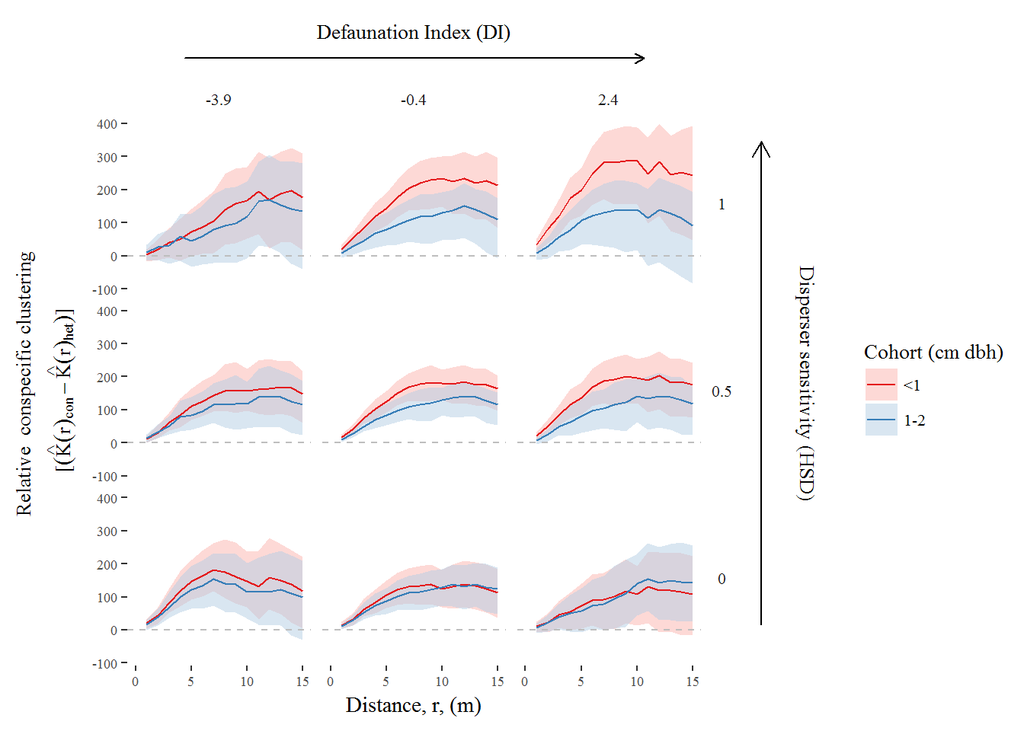

```r
## Univariate plot
z.uni <- ggplot_gtable(ggplot_build(pl.int.uni))
##gtable_show_layout(z.uni)

## add labels at the top and side
z.uni <- gtable_add_rows(z.uni, height=unit(z.uni$heights[[6]], 'cm'),  pos=5) ## top arrow
z.uni <- gtable_add_rows(z.uni, height=unit(z.uni$heights[[6]], 'cm'),  pos=5) ## top label
z.uni <- gtable_add_cols(z.uni, width=unit(z.uni$widths[[9]], 'cm'), pos=9) # right label
z.uni <- gtable_add_cols(z.uni, width=unit(z.uni$widths[[9]], 'cm'), pos=9) # Right arrow
z.uni <- gtable_add_cols(z.uni, width=z.uni$widths[[2]], pos=1) ## outer left Y axis

z.uni <- gtable_add_grob(z.uni,
                     list(rectGrob(gp = gpar(fill=NA, col=NA, lwd=0)),
                          textGrob("Relative  conspecific clustering", rot = 90,
                                   gp = gpar(fontsize=10, fontfamily="serif"))),
                     t=8, l=2, b=14, r=2, name = paste(runif(2)))
## add defaunation label
z.uni <- gtable_add_grob(z.uni,
                         list(rectGrob(gp=gpar(fill=NA, col=NA, lwd=0)),
                              textGrob("Defaunation Index (DI)",
                                       gp = gpar(fontsize=10, fontfamily="serif"))),
                         t=6, l=5, b=6, r=9, name = paste(runif(2)))

z.uni <- gtable_add_grob(z.uni,
                        linesGrob(x=seq(0.1, 0.9, 0.1), y=rep(0.7, 9),
                                  arrow=arrow(angle=30, length=unit(0.3, "npc"))),
                        t=7, l=5, b=7, r=9, name = paste(runif(1)))
## add disperser sensitivity label

z.uni <- gtable_add_grob(z.uni,
                         list(rectGrob(gp = gpar(fill=NA, col=NA, lwd=0)),
                              textGrob("Disperser sensitivity (HSD)", rot = -90,
                                       gp = gpar(fontsize=10, fontfamily="serif"))),
                         t=8, l=12, b=14, r=12, name = paste(runif(2)))

z.uni <- gtable_add_grob(z.uni,
                        linesGrob(x=rep(0.7, 9), y=seq(0.1, 0.9, 0.1),
                                  arrow=arrow(length=unit(0.2, "npc"))),
                        t=8, l=11, b=14, r=10, name = paste(runif(1)))

ggdraw(z.uni)
```

```r
## Knitr seems to mess the exports up, so just doing them manually.
## Do not run this unless you want to change figures (and have done at least 999 iterations
## commented out to prevent mistakes

if(nsim >= 999){
  png(file='../../huntingpaper/JEcol/figures/revision/Figure1_uni.png', width=6, height=4, units='in', res=600)
  ggdraw(z.uni)
  dev.off()

  pdf(file='../../huntingpaper/JEcol/figures/revision/Figure1a_uni.pdf', width=6, height=4)
  ggdraw(z.uni)
  dev.off()

  png(file='../../huntingpaper/JEcol/figures/revision/Figure3_bi.png', width=6, height=4, units='in', res=600)
  ggdraw(z.bi)
  dev.off()

  pdf(file='../../huntingpaper/JEcol/figures/revision/Figure3_bi.pdf', width=6, height=4)
  ggdraw(z.bi)
  dev.off()

}
```

## 5 Ploting of individual species

We can plot the individual K-functions for each species x site combination. First we remove K functions based on < 15 individuals, which are meaningless on their own but can contribute with low weight to an overall analysis. We then need to select species that are represented in both cohorts at at least one hunted and one non-hunted site.

```r
hyperdat.uni.ind <- subset(hyperdat.uni.sel.c, N1 > 15) ## & stage %in%
##                             c("dbh_0", "dbh_1"))

hyperdat.uni.ind$Spp <- droplevels(hyperdat.uni.ind$Spp)
counts <- table(hyperdat.uni.ind$Spp, hyperdat.uni.ind$site)
counts <- as.matrix(counts)
## only include species that are represented in at least 1 hunted and one intact site (note
# that if a site has a species there will be 3 rows (<1, 1-2 and 2-5 cm dbh)
counts <- counts[apply(counts, 1, function(x) any(x[c(1, 4, 5)] > 1) & any(x[c(2, 3, 6)] > 1)),]
sp.keep <- rownames(counts)
length(sp.keep) ## number of species that qualify
```

```
## [1] 20
```

```r
## Pulling out selected species
hyperdat.uni.ind <- subset(hyperdat.uni.sel.c, Spp %in% sp.keep)
hyperdat.bi.ind <- subset(hyperdat.bi.sel.c, Spp %in% sp.keep)
hyperdat.uni.ind <- hyperdat.uni.ind[order(hyperdat.uni.ind$N1),]
ntotals <- aggregate(N1 ~ Spp, data=subset(hyperdat.uni.sel.c, Spp %in% sp.keep), sum)
ntotals <- ntotals[rev(order(ntotals$N1)),]
disptype <- aggregate(HSD ~ Spp, data=hyperdat.uni.ind, mean)
## add dispersal data
disptype <- merge(disptype, ntotals)
```

Now we can select the most abundant species and plot them

```r
## order species by abundance
disptype <- disptype[order(disptype$N1, decreasing=T),]
head(disptype)
```

|  | Spp | HSD | N1 |
| --- | --- | --- | --- |
| 4 | Guarea kunthiana | 0.0 | 1566 |
| 13 | Pseudolmedia laevis | 0.7 | 1154 |
| 5 | Guarea macrophylla | 0.0 | 943 |
| 10 | Otoba parvifolia | 0.0 | 833 |
| 15 | Quararibea wittii | 0.6 | 801 |
| 11 | Oxandra acuminata | 0.5 | 645 |

```r
## The subsetting in this function which will determine which species are included
## Including 1:4 so that 4 most abundant species are included
## If more are included we need to modify the plot code too

## two most abundant species in the high and low disperser sensitivity categories
sp2plot <- c(as.character(disptype$Spp[disptype$HSD<0.5][1:2]),
             as.character(disptype$Spp[disptype$HSD>0.5][1:2]))

ind.funcs <- hyperdat.uni.ind[hyperdat.uni.ind$Spp %in% sp2plot]
ind.funcs <- ind.funcs[order(ind.funcs$HSD)]
ind.funcs$Spp <- droplevels(ind.funcs$Spp)

sp.mods <- lapply(split(ind.funcs, f=ind.funcs$Spp), function(sp.dat){
  sp.mod <- ReplicatedPointPatterns::lmHyperframe(sp.dat, 0:15, "stage*hunted", computeK=FALSE, minsamp=NA)
  preddat <- expand.grid(stage=levels(sp.dat$stage), hunted=levels(sp.dat$hunted))
  Xmat <- model.matrix(~stage*hunted, preddat)
  sp.boot  <- ReplicatedPointPatterns::lm.t.boot(sp.mod,lincomb=Xmat, nsim=nsim, alpha=0.05, simple=FALSE)
  sp.dat <- with(sp.boot, {
    data.frame(
      Spp = unique(sp.dat$Spp),
      do.call('rbind', replicate(15, preddat, simplify=FALSE)),
      r=rep(1:15, each=nrow(preddat)),
      K=(do.call('c', lmKpred)),
      ucl=do.call('c', upper),
      lcl=do.call('c', lower)
    )})
})

sp.mods <- do.call('rbind', sp.mods)
sp.mods$hunted <- factor(sp.mods$hunted, levels=c('intact', 'hunted'),
                           labels=c('3 least hunted sites', '3 most hunted sites'))
sp.mods$stage <- factor(sp.mods$stage, labels=dbhlabs)

ind.funcs <- do.call('rbind', lapply(1:nrow(ind.funcs), function(i, dat){
  dat.i <- dat[i,]
  Ki <- data.frame(dat.i$K)[,c(1,3)]
  names(Ki) <- c('r', 'K')
  dat.i <- cbind(as.data.frame(dat.i[, c('stage', 'N1', 'N2', 'Spp', 'site',
                                         'pname', 'hunted', 'huntpres')]), Ki)
  return(dat.i)
}, dat=ind.funcs))

ind.funcs$stage <- factor(ind.funcs$stage, labels=dbhlabs)
ind.funcs$Spp <-  factor(ind.funcs$Spp, levels=unique(ind.funcs$Spp))

ind.funcs$N <-  ntotals$N1[match(ind.funcs$Spp, ntotals$Spp)]
ind.funcs$HSD <- disptype$HSD[match(ind.funcs$Spp, disptype$Spp)]
ind.funcs$splab <- paste(ind.funcs$Spp, ' (n = ', ind.funcs$N, ')', sep='')
ind.funcs$hunted <- factor(ind.funcs$hunted, levels=c('intact', 'hunted'),
                           labels=c('3 least hunted sites', '3 most hunted sites'))

ind.funcs$site.lab <- ind.funcs$pname
ind.funcs$site.lab[ind.funcs$r != 13] <- NA
```

We can now prepare the plot and customise it to display all the information we need.

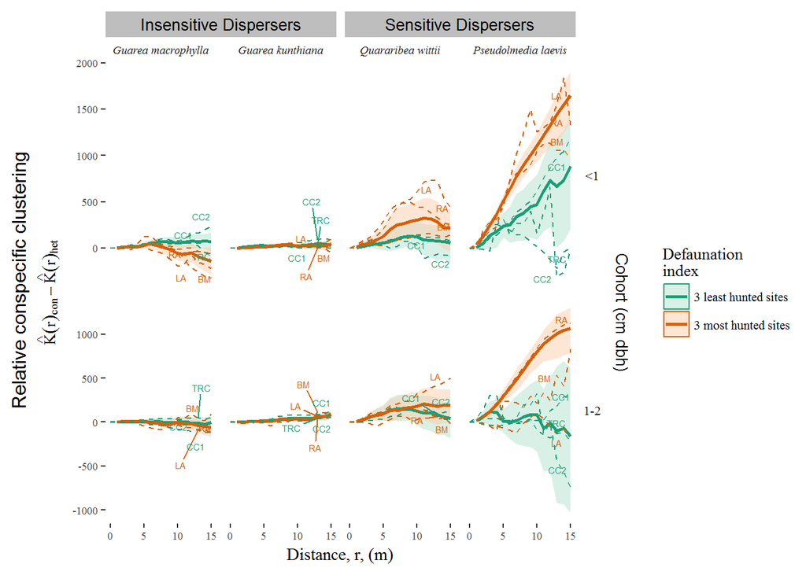

```r
sp.plot  <- ggplot(data=ind.funcs, aes(x=r, y=K)) +
  geom_ribbon(data=sp.mods,
              aes(ymin=lcl, ymax=ucl, colour=NULL, fill=hunted, group=hunted), alpha=0.5) +
  geom_line(data=sp.mods, aes(colour=hunted, group=hunted), size=1) +
  geom_line(aes(colour=hunted, group=stage:site), linetype='dashed') +
  geom_text_repel(aes(label=site.lab, col=hunted), size=2, show.legend=FALSE) + ##,) segment.color=0) +
  facet_grid(stage~ Spp, scales='free') +
    scale_colour_brewer(palette='Dark2') +
  scale_fill_brewer(palette='Pastel2') +
  ##geom_abline(intercept=0, lty='dashed', col='grey50') +
  theme_tufte() + theme_cust +
  labs(x='Distance, r, (m)', y=expression(hat(K)(r)[con]-hat(K)(r)[het]),
       colour='Defaunation\nindex', fill="Defaunation\nindex")
sp.plot <-
  sp.plot + theme(strip.text.x=element_text(size=7, face='italic'))##,
##                  strip.background=element_rect(fill="white", colour="white"))

z.sp <- ggplot_gtable(ggplot_build(sp.plot))
##gtable_show_layout(z.sp)
## add a label at the top and side

z.sp <- gtable_add_rows(z.sp, height=z.sp$heights[6], pos=5)
z.sp <- gtable_add_cols(z.sp, width=z.sp$heights[6], pos=12)
z.sp <- gtable_add_cols(z.sp, width=z.sp$widths[2], pos=1)
##sapply(z.test$grobs[grep('strip.absoluteGrob', sapply(z.test$grobs, function(x) x$name))], function(x) x$children[[1]]$gp$fill)

z.sp <- gtable_add_grob(z.sp,
                     list(rectGrob(gp = gpar(fill=NA, col=NA, lwd=0)),
                          textGrob("Relative conspecific clustering", rot = 90,
                                   gp = gpar(fontsize=12))),
                     t=7, l=2, b=6+length(dbhlabs)*2, r=2, name = paste(runif(2)))

z.sp <- gtable_add_grob(z.sp,
                     list(rectGrob(gp=gpar(fill='grey', col='grey', lwd=0.2)),
                          textGrob("Insensitive Dispersers",
                                   gp = gpar(fontsize=10))),
                     t=6, l=5, b=6, r=7, name = paste(runif(2)))
z.sp <- gtable_add_grob(z.sp,
                     list(rectGrob(gp=gpar(fill='grey', col='grey', lwd=0.2)),
                          textGrob("Sensitive Dispersers",
                                   gp = gpar(fontsize=10))),
                     t=6, l=9, b=6, r=11, name = paste(runif(2)))

z.sp <- gtable_add_grob(z.sp,
                     list(rectGrob(gp = gpar(fill='white', col='white', lwd=0.2)),
                          textGrob("Cohort (cm dbh)", rot = -90,
                                   gp = gpar(fontsize=10))),
                     t=8, l=14, b=12, r=14, name = paste(runif(2)))

ggdraw(z.sp)
```

```r
pdf('../../huntingpaper/JEcol/figures/revision/Figure2_bysp.pdf', width=8, height=4)
ggdraw(z.sp)
dev.off()
```

```r
png('../../huntingpaper/JEcol/figures/revision/Figure2_bysp.png', width=8, height=4, units='in', res=600)
ggdraw(z.sp)
dev.off()
```

We might also want to repeat for all species to make supplemental figure.

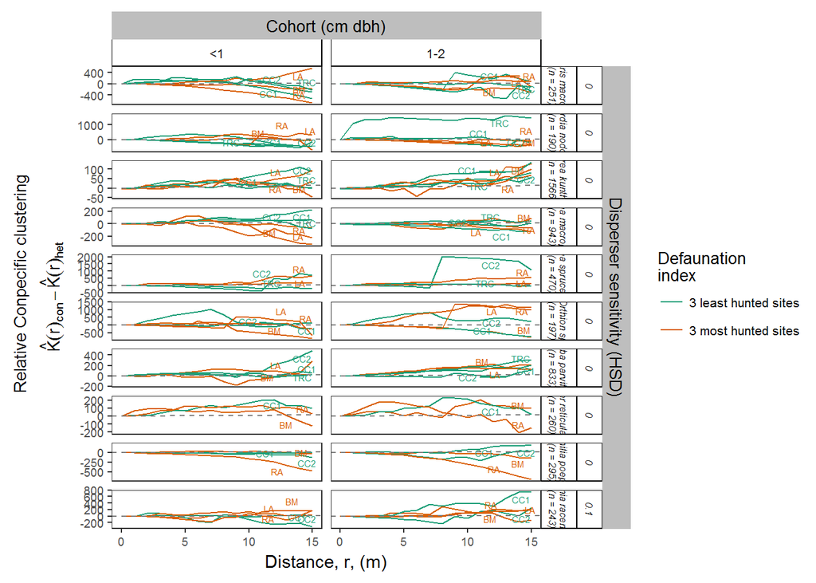

```r
ind.funcs.all <- hyperdat.uni.ind
ind.funcs.all <- ind.funcs.all[order(ind.funcs.all$HSD)]
ind.funcs.all$Spp <- droplevels(ind.funcs.all$Spp)

ind.funcs.all <- do.call('rbind', lapply(1:nrow(ind.funcs.all), function(i, dat){
  dat.i <- dat[i,]
  Ki <- data.frame(dat.i$K)[,c(1,3)]
  names(Ki) <- c('r', 'K')
  dat.i <- cbind(as.data.frame(dat.i[, c('stage', 'N1', 'N2', 'Spp', 'site',
                                         'pname', 'hunted', 'huntpres')]), Ki)
  return(dat.i)
}, dat=ind.funcs.all))

ind.funcs.all$stage <- factor(ind.funcs.all$stage, labels=dbhlabs)

##ind.funcs.all$stage <- factor(ind.funcs.all$stage, labels=c('Saplings', 'Juveniles'))
## order by disperser sensitivity
ind.funcs.all$Spp <-  droplevels(factor(ind.funcs.all$Spp, levels=disptype$Spp))

# ind.funcs.all$N <-  ntotals$N1[match(ind.funcs.all$Spp, ntotals$Spp)]
# ind.funcs.all$HSD <- disptype$HSD[match(ind.funcs.all$Spp, disptype$Spp)]
# ind.funcs.all$splab <- paste(ind.funcs.all$Spp, ' (n = ', ind.funcs.all$N, ')', sep='')
# ind.funcs.all$hunted <- factor(ind.funcs.all$hunted, levels=c('intact', 'hunted'),
#                            labels=c('Low', 'High'))

ind.funcs.all$site.lab <- ind.funcs.all$pname
ind.funcs.all$site.lab[ind.funcs.all$r != 13] <- NA

ind.funcs.all$N <-  ntotals$N1[match(ind.funcs.all$Spp, ntotals$Spp)]
ind.funcs.all$HSD <- disptype$HSD[match(ind.funcs.all$Spp, disptype$Spp)]
ind.funcs.all$splab <- paste(ind.funcs.all$Spp, '\n(n = ', ind.funcs.all$N, ')', sep='')
hsdbysp <- aggregate(HSD ~ splab, data=ind.funcs.all, unique)
hsdbysp <- hsdbysp[order(hsdbysp$HSD),]
ind.funcs.all$splab <- factor(ind.funcs.all$splab, levels=hsdbysp$splab)
ind.funcs.all$hunted <- factor(ind.funcs.all$hunted, levels=c('intact', 'hunted'),
                           labels=c('3 least hunted sites', '3 most hunted sites'))

plotgrps <- list(hsdbysp$splab[1:10], hsdbysp$splab[11:20])

sp.plot.all  <- lapply(plotgrps, function(grp)
  {

  ggplot(subset(ind.funcs.all, splab %in% grp), aes(x=r, y=K, colour=hunted, group=stage:site),
         fill='white')+
    geom_line() + geom_text_repel(aes(label=site.lab), size=2, show.legend=FALSE) +
    facet_grid(HSD + splab   ~stage, scales='free') +

    scale_colour_brewer(palette='Dark2') +
    geom_abline(intercept=0, lty='dashed', col='grey50') + theme_bw() + theme_cust +
    labs(x='Distance, r, (m)', y=expression(hat(K)(r)[con]-hat(K)(r)[het]),
         color='Defaunation\nindex') +
    theme(strip.text.y=element_text(size=6, face='italic', angle=270),
          strip.background=element_rect(colour="black"))
})


z.sp.all <- lapply(sp.plot.all, function(pl) ggplot_gtable(ggplot_build(pl)))
##gtable_show_layout(z.sp.all[[1]])
## add a labels at the top and sides

z.sp.all <- lapply(z.sp.all, function(z)
{
  z <- gtable_add_rows(z, height=unit(z$heights[[6]], 'cm'), pos=5)
  z <- gtable_add_cols(z, width=unit(z$heights[[6]], 'cm'), pos=8)

  ## add header row with stage label
  z <- gtable_add_grob(z,list(rectGrob(gp=gpar(fill='grey', col='grey', lwd=0.2)),
                       textGrob("Cohort (cm dbh)",
                                gp = gpar(fontsize=10))),
                  t=6, l=4, b=6, r=6, name = paste(runif(2)))
  ## add column with disperser senstitivity label
  barlngth <-  length(z$heights) -4

  z <- gtable_add_grob(z,list(rectGrob(gp = gpar(fill='grey', col='grey', lwd=0.2)),
                                   textGrob("Disperser sensitivity (HSD)", rot = -90,
                                            gp = gpar(fontsize=10))),
                              t=8, l=9, b=barlngth, r=9, name = paste(runif(2)))

  z <- gtable_add_cols(z, width=z$widths[[2]], pos=1)

  z <- gtable_add_grob(z, list(rectGrob(gp = gpar(fill=NA, col=NA, lwd=0)),
                                   textGrob("Relative Conpecific clustering", rot = 90,
                                            gp = gpar(fontsize=10))),
                              t=7, l=2, b=barlngth, r=2, name = paste(runif(2)))
  return(z)
  })

z <- z.sp.all[[1]]
ggdraw(z)
```

```r
pdf('../../huntingpaper/JEcol/figures/revision/FigS1_byspecies_2pg_new.pdf', paper='A4', width=7, height=10)
lapply(z.sp.all, function(z) ggdraw(z))
```

```r
dev.off()
```

## 6 Description of data set

Extracing some summaries of the data to report in the paper

Some numbers on number of individuals/species etc etc

```r
##reliance on different dispersers
disp.list.uni <-  aggregate(cbind(LV, SV, SB, Bat, TR, Wind, Expl) ~Spp,
                            subset(hyperdat.uni.sel.c,
                                   stage==levels(hyperdat.uni.sel$stage)[1]), unique)
disp.list.bi <-  aggregate(cbind(LV, SV, SB, Bat, TR, Wind, Expl) ~Spp,
                           subset(hyperdat.bi.sel.c,
                                  stage==levels(hyperdat.uni.sel$stage)[1]), unique)
## Merge data from univariate and bivariate analyses
disp.list <- merge(disp.list.uni, disp.list.bi, by="Spp", all=T, suffix=c('uni', 'bi'))

## calculate number of species in each dispersal group
apply(disp.list[, -1], 2, function(x) sum(x>0, na.rm=T)) ## number dependent to some degree
```

```
##   LVuni   SVuni   SBuni  Batuni   TRuni Winduni Expluni    LVbi    SVbi    SBbi
##     117      70      75      22      10       0       0      98      60      59
##   Batbi    TRbi  Windbi  Explbi
##      19      11       0       0
```

```r
apply(disp.list[, -1], 2, function(x) sum(x==1, na.rm=T)) ## number totally dependent
```

```
##   LVuni   SVuni   SBuni  Batuni   TRuni Winduni Expluni    LVbi    SVbi    SBbi
##      28       2      28       8       0       0       0      21       1      25
##   Batbi    TRbi  Windbi  Explbi
##       7       1       0       0
```

```r
apply(disp.list[, -1], 2, function(x) sum(!is.na(x))) ## Total number of vertebrate dispersed species
```

```
##   LVuni   SVuni   SBuni  Batuni   TRuni Winduni Expluni    LVbi    SVbi    SBbi
##     174     174     174     174     174     174     174     146     146     146
##   Batbi    TRbi  Windbi  Explbi
##     146     146     146     146
```

```r
29/178; 25/155
```

```
## [1] 0.163
```

```
## [1] 0.161
```

```r
121/178; 104/155 ## proportion large vertebrate dispersed
```

```
## [1] 0.68
```

```
## [1] 0.671
```

```r
## Number of stems in each life stage.
aggregate(N1 ~ stage, hyperdat.uni.sel.c, sum) ##  univariate analysis
```

| stage | N1 |
| --- | --- |
| dbh_0 | 8315 |
| dbh_1 | 9157 |

```r
aggregate(N1 ~ stage, hyperdat.bi.sel.c, sum) ## bivariate analysis
```

| stage | N1 |
| --- | --- |
| dbh_0 | 6329 |
| dbh_1 | 6920 |

```r
aggregate(N2 ~ stage, hyperdat.bi.sel.c,  sum) ## number of adults in bivariate
```

| stage | N2 |
| --- | --- |
| dbh_0 | 5905 |
| dbh_1 | 5905 |

```r
aggregate(Spp ~ pname, hyperdat.uni.sel.c, function(x) length(unique(x))) # species per site
```

| pname | Spp |
| --- | --- |
| BM | 62 |
| CC1 | 86 |
| CC2 | 82 |
| LA | 69 |
| RA | 72 |
| TRC | 57 |

```r
aggregate(Spp ~ pname, hyperdat.bi.sel.c, function(x) length(unique(x))) # species per site
```

| pname | Spp |
| --- | --- |
| BM | 40 |
| CC1 | 58 |
| CC2 | 61 |
| LA | 43 |
| RA | 53 |
| TRC | 51 |